# 632 Project

```r
library(tidyverse)
library(stringr)
library(randomForest)
library(vip)
library(rpart)
library(rpart.plot)
library(caret)
```

## Research Data

The dataset contains **2515 unique videos** and their **subtitles** from over **91 different YouTubers**, ranging from all different kinds of categories.

```r
df_raw <- read.csv("data.csv")
head(df_raw)
```

|  | Id | Channel | Subscribers | Title | CC | URL | Released | Views | Category | Transcript | Length |
| --- | --- | --- | --- | --- | --- | --- | --- | --- | --- | --- | --- |
| 1 | FozCkl1xj-w | JRE Clips | 6.28M subscribers | Former CIA Agent Breaks Down Jeffrey Epstein Case | 0 | https://www.youtube.com/watch?v=FozCkl1xj-w | 2 years ago | 7.9M views | Blog | the Joe Rogan experience well how about the other so you gotta go to okay how about the other prints the one that's Epstein's friend toe Oh Andrew yeah yeah that was that was what first of all how odd… | 13:32 |
| 2 | RN8yoi-e2yc | Mythical Kitchen | 1.9M subscribers | $420 Pizza Hut Stuffed Crust Pizza \| Fancy Fast Food \| Mythical Kitchen | 1 | https://www.youtube.com/watch?v=RN8yoi-e2yc |  | 2.7M views | Food | - Oh, that's dirty.\n- Wow! - Whoa.\n- You're a dirty girl. (upbeat music) - Hey man. - What'd you get, man? How'd you get in my car? - Uh, well, we started in here. So, this is Pizza Hut,\nStuffed Cr… | 24:26 |
| 3 | IugcIAAZJ2M | Munchies | 4.59M subscribers | The Iconic $1 Pizza Slice of NYC \| Street Food Icons | 0 | https://www.youtube.com/watch?v=IugcIAAZJ2M | 2 years ago | 11M views | Food | if you want good pizza come to st marks it's the best pizza i'll be in any borough i always come and say marks i know about two birds so they love me in there i shop every day in there i got two slice… | 7:51 |
| 4 | JiEO6F8i0eU | Parks and Recreation | 282K subscribers | Ron Swanson: The Papa of Pawnee \| Parks and Recreation | 0 | https://www.youtube.com/watch?v=JiEO6F8i0eU | 3 years ago | 2.3M views | Entertainment,Comedy | April where have you been over two phone calls came in uninvited we're raising money for my college education wrong I took a second job back at my old job do you want to see shine it's $100 laugh all … | 10:06 |
| 5 | 1T4XMNN4bNM | Vsauce | 17.4M subscribers | What's The Most Dangerous Place on Earth? | 1 | https://www.youtube.com/watch?v=1T4XMNN4bNM | 9 years ago | 21M views | Science | Hey, Vsauce. Michael here. 93% of all the\nhumans who have ever lived are dead. For every person alive right now, there are 15 people\nwho are no longer alive. The Earth is dangerous...but where is th… | 9:29 |
| 6 | 0ZWGeidvrJw | Doctor Who | 1.59M subscribers | The Doctor Defeats the Abzorbaloff \| Love and Monsters \| Doctor Who | 1 | https://www.youtube.com/watch?v=0ZWGeidvrJw | 7 years ago | 8.5M views | Entertainment | Oh, what's the matter?\nHave you given up so soon? There's no point. Where would I go? Everything I ever wanted... Has been absorbed. Oh, Elton, don't say that. But it's true! Then join us. Join us, l… | 4:20 |

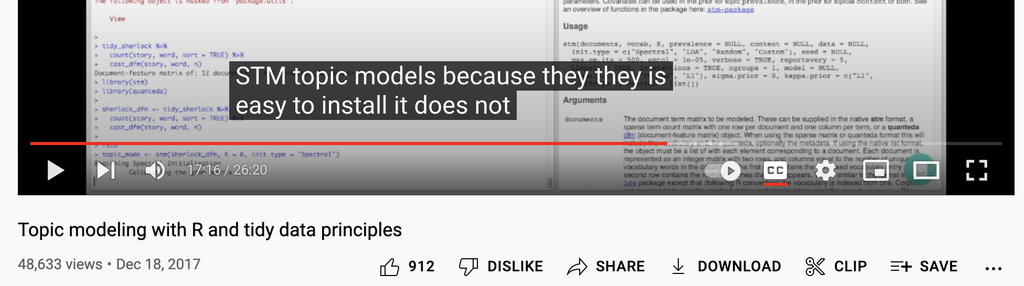

Youtube Video

## Research Goal

Conduct a sentiment analysis on the subtitles. Try various statistical models like linear regression, decision tree and random forest. Find the best model to predict the number of views using Subscribers, CC, Released, Category, Sentiment and Length.

## Data Cleaning

We notice several problems in the data, like:

1. Views: The Views variable is in string format and the units are different, like “10K views”, “10M views”. We prefer it to be in number and in the same unit in order to conduct statistical analysis.
2. Subscribers: The same problems as Views. The Subscribers variable is like “10K subscribers”, “10M subscribers”.
3. Length: The video length is in string format, like “12:00”, “1:12:00”. We need it to be in number and in the same unit.
4. Released: The Released variable is in string format, like “2 years age”, “10 month ago”. We need it to be in number and in the same unit.

Therefore, we need to do data cleaning first.

```r
# Unify units and convert string to number, like: 10K views -> 10, 10M views -> 10000
cleanViews <- function(str) {
  str <- str_remove(str, " views")
  last <- str_sub(str, -1)
  views <- str %>% str_remove(last) %>% as.numeric()
  if (last == "M") return(1000*views)
  else return(views)
}

# Unify units and convert string to number, like: 10K subscribers -> 10, 10M subscribers -> 10000
cleanSubscribers <- function(str) {
  str <- str_remove(str, " subscribers")
  last <- str_sub(str, -1)
  views <- str %>% str_remove(last) %>% as.numeric()
  if (last == "M") return(1000*views)
  else return(views)
}

# Convert time in string format to number of minutes, like: 12:00 -> 12, 1:12:00 -> 72
cleanLength <- function(str) {
  list <- str_split(str, ":")
  len <- length(list[[1]])
  if (len == 3) {
     h <- as.numeric(list[[1]][1])
     m <- as.numeric(list[[1]][2])
     return((m + 1) + 60*m)
  } else {
     m <- as.numeric(list[[1]][1])
     return(m+1)
  }
}

# Convert time to number of months ago, like: 1 years ago -> 12, 10 months ago to 10
cleanReleased <- function(str) {
  str <- str_remove(str, "Streamed ")
  list <- str_split(str, " ")
  if (list[[1]][2] == "years") return(as.numeric(list[[1]][1])*12)
  else return(as.numeric(list[[1]][1]))
}

# Remove NAs
df <- df_raw %>%
  filter(
    !is.na(Released) & Released != ""
  )

# Clean the data
df <- df %>% mutate(
  Views = map_dbl(Views, cleanViews),
  Subscribers = map_dbl(Subscribers, cleanSubscribers),
  Length = map_dbl(Length, cleanLength),
  Released = map_dbl(Released, cleanReleased)
)

head(df)

# Save for future use
write_csv(df, "cleaned_data.csv")
```

## Data Discovery

```r
df <- read_csv("cleaned_data.csv")
df$CC <- as.factor(df$CC)
df$Category <- as.factor(df$Category)
df$Subscribers <- as.numeric(df$Subscribers)

head(df)
```

| Id | Channel | Subscribers | Title | CC | URL | Released | Views | Category | Transcript | Length |
| --- | --- | --- | --- | --- | --- | --- | --- | --- | --- | --- |
| FozCkl1xj-w | JRE Clips | 6280 | Former CIA Agent Breaks Down Jeffrey Epstein Case | 0 | https://www.youtube.com/watch?v=FozCkl1xj-w | 24 | 7900 | Blog | the Joe Rogan experience well how about the other so you gotta go to okay how about the other prints the one that's Epstein's friend toe Oh Andrew yeah yeah that was that was what first of all how odd… | 14 |
| IugcIAAZJ2M | Munchies | 4590 | The Iconic $1 Pizza Slice of NYC \| Street Food Icons | 0 | https://www.youtube.com/watch?v=IugcIAAZJ2M | 24 | 11000 | Food | if you want good pizza come to st marks it's the best pizza i'll be in any borough i always come and say marks i know about two birds so they love me in there i shop every day in there i got two slice… | 8 |
| JiEO6F8i0eU | Parks and Recreation | 282 | Ron Swanson: The Papa of Pawnee \| Parks and Recreation | 0 | https://www.youtube.com/watch?v=JiEO6F8i0eU | 36 | 2300 | Entertainment,Comedy | April where have you been over two phone calls came in uninvited we're raising money for my college education wrong I took a second job back at my old job do you want to see shine it's $100 laugh all … | 11 |
| 1T4XMNN4bNM | Vsauce | 17400 | What's The Most Dangerous Place on Earth? | 1 | https://www.youtube.com/watch?v=1T4XMNN4bNM | 108 | 21000 | Science | Hey, Vsauce. Michael here. 93% of all the\nhumans who have ever lived are dead. For every person alive right now, there are 15 people\nwho are no longer alive. The Earth is dangerous...but where is th… | 10 |
| 0ZWGeidvrJw | Doctor Who | 1590 | The Doctor Defeats the Abzorbaloff \| Love and Monsters \| Doctor Who | 1 | https://www.youtube.com/watch?v=0ZWGeidvrJw | 84 | 8500 | Entertainment | Oh, what's the matter?\nHave you given up so soon? There's no point. Where would I go? Everything I ever wanted... Has been absorbed. Oh, Elton, don't say that. But it's true! Then join us. Join us, l… | 5 |
| YiEj9mrqTN0 | A&E | 7930 | Live PD: Most Viewed Moments from Walton County, FL \| A&E | 1 | https://www.youtube.com/watch?v=YiEj9mrqTN0 | 24 | 14000 | News | [music playing] We'll be on Laverne Street. It's a red Dodge pickup. This whole not stopping\nthing is kind of interesting. No, you good. Yeah. Your taillight's not working.\nThat's why I stopped you.… | 21 |

```r
table(df$CC)
```

```
##
##    0    1
## 1094 1004
```

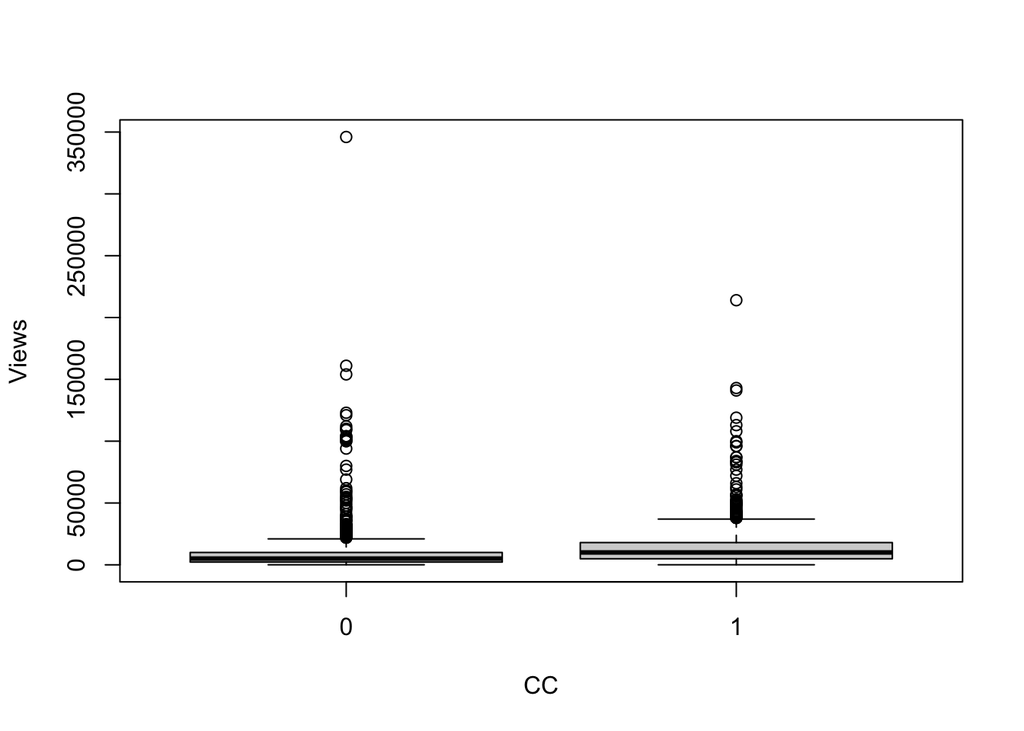

```r
boxplot(Views ~ CC, data = df)
```

```r
summary(df$Length)
```

```
##    Min. 1st Qu.  Median    Mean 3rd Qu.    Max.
##    1.00    6.00   11.00   26.94   17.00 3539.00
```

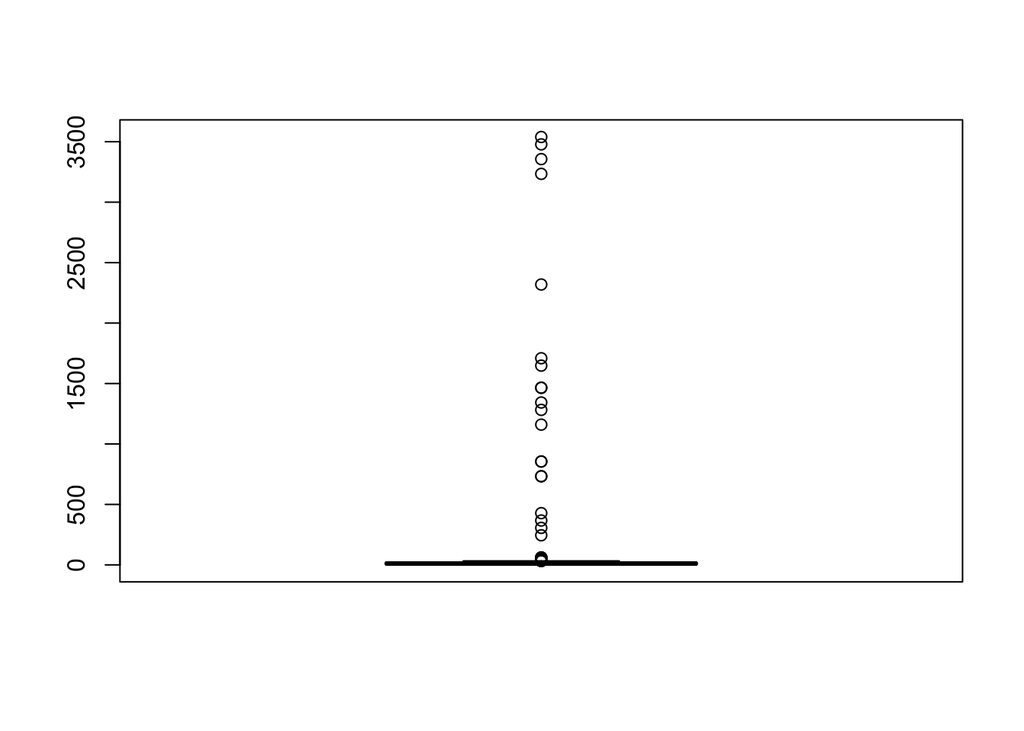

```r
boxplot(df$Length)
```

```r
summary(df$Released)
```

```
##    Min. 1st Qu.  Median    Mean 3rd Qu.    Max.
##    2.00   24.00   36.00   46.46   60.00  156.00
```

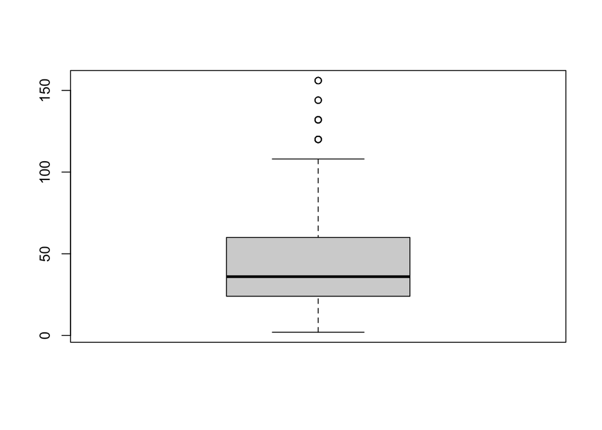

```r
boxplot(df$Released)
```

```r
summary(df$Subscribers)
```

```
##    Min. 1st Qu.  Median    Mean 3rd Qu.    Max.
##     179    1730    4010    6871    8240   89700
```

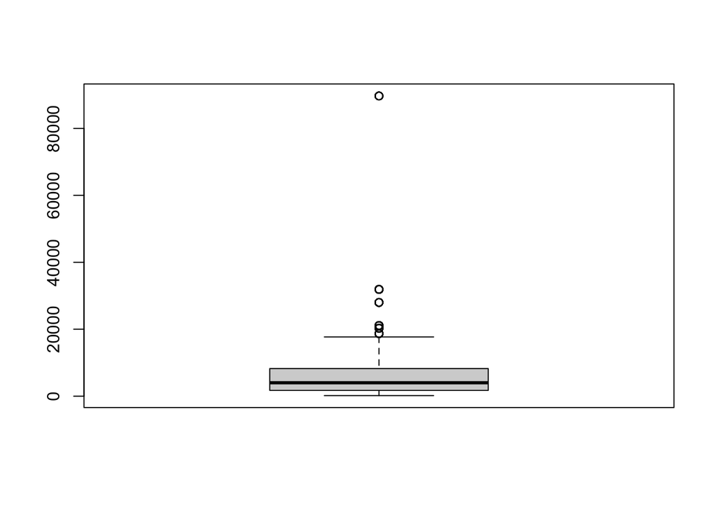

```r
boxplot(df$Subscribers)
```

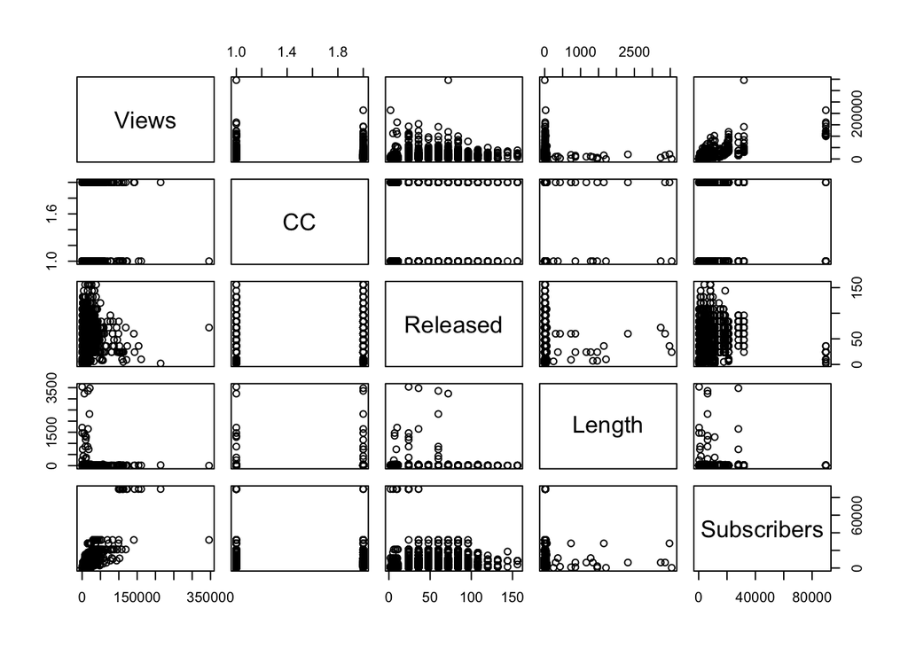

```r
pairs(Views ~ CC + Released + Length + Subscribers, data=df)
```

## Preparation for Cross-Validation

Randomly split the data set in a 70% training and 30% test set. Make sure to use set.seed() so that your results are reproducible

```r
set.seed(652)
n <- nrow(df)
train_index <- sample(1:n, round(0.7*n))
df_train <- df[train_index,]
df_test <- df[-train_index,]
```

## Regression Tree

### Fit a regression tree on the training set.

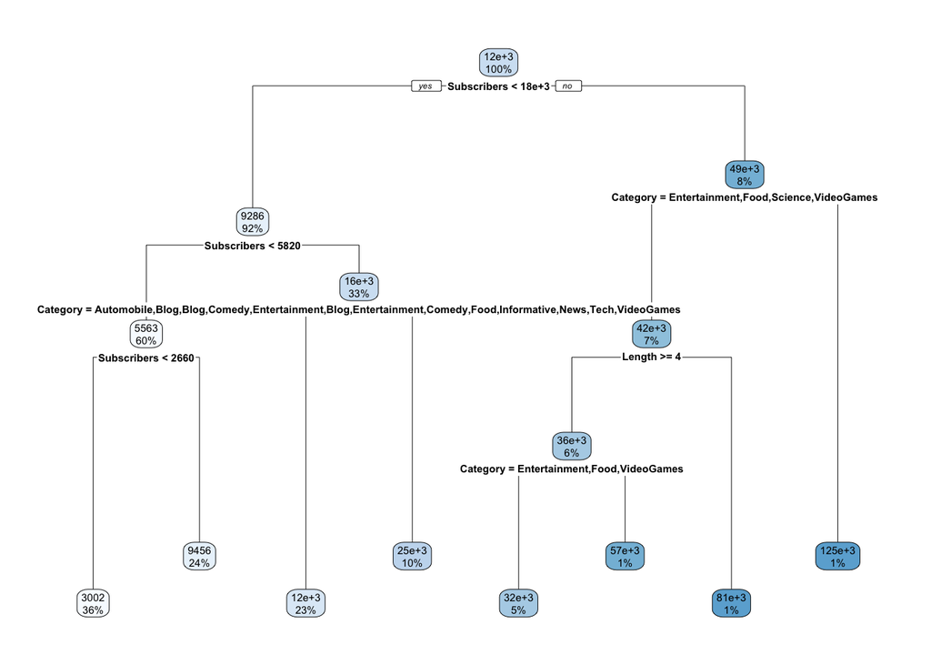

```r
# Fit tree model
t1 <- rpart(Views ~ CC + Released + Category + Length + Subscribers,
            data = df_train,
            method = "anova")

# Plot the desicion tree
rpart.plot(t1)
```

[output not shown]

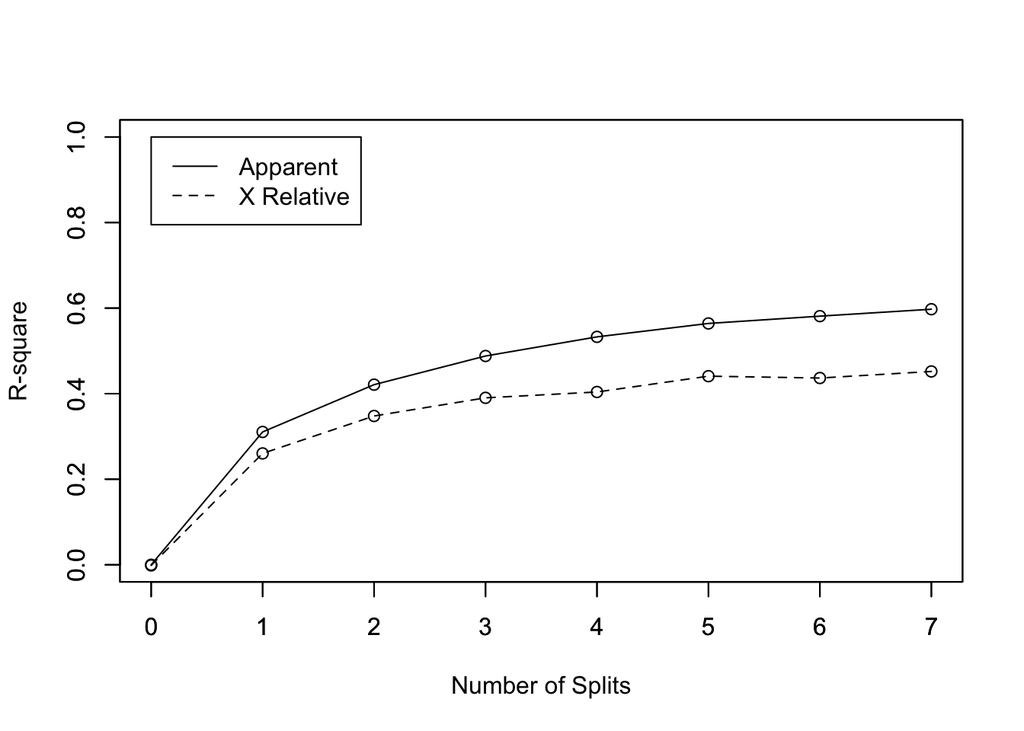

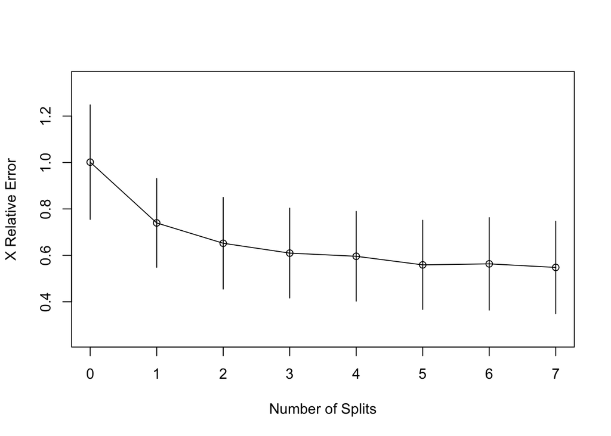

```r
# Plot R-square vs Splits and the Relative Error vs Splits.
rsq.rpart(t1)
```

### Make predictions on the test set and compute the RMSE

```r
# Make prediction
pred_tree <- predict(t1, newdata = df_test)

# Compute the RMSE
RMSE(df_test$Views, pred_tree)
```

```
## [1] 7977.73
```

## Random Forest

### Fit a Random Forest on the training set usinng the defaults for mtry and ntree.

```r
set.seed(652)
rf1 <- randomForest(Views ~ CC + Released + Category + Length + Subscribers, importance = TRUE, data = df_train)
rf1
```

```
##
## Call:
##  randomForest(formula = Views ~ CC + Released + Category + Length +      Subscribers, data = df_train, importance = TRUE)
##                Type of random forest: regression
##                      Number of trees: 500
## No. of variables tried at each split: 1
##
##           Mean of squared residuals: 175526230
##                     % Var explained: 49.65
```

Use the `vip()` function to make a variable importance plot. Which variables are most important?

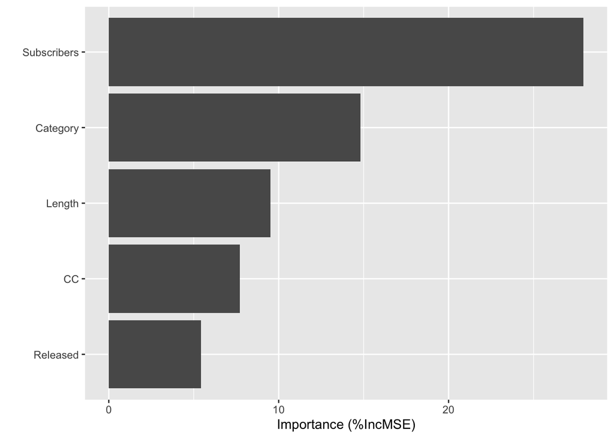

```r
vip(rf1, num_features = 14,  include_type = TRUE)
```

### Make predictions on the test set and compute the RMSE

```r
# Make prediction
pred_rf <- predict(rf1, newdata = df_test)

# Compute the RMSE
RMSE(df_test$Views, pred_rf)
```

```
## [1] 7645.176
```

[output not shown]